Student Names: Tamer Kobba 202104873 Jalal EL Zein 202105966

# Introduction

In the quest for understanding and safeguarding our planet from potential cosmic threats, the analysis of Near-Earth Objects (NEOs) takes center stage. Leveraging data from NASA’s API on NEOs, this report delves into the development of machine learning models aimed at classifying these celestial entities as hazardous or non-hazardous. The urgency of this research lies in the profound implications of a collision with a hazardous NEO, as evidenced by historical cosmic events. By harnessing the power of machine learning, we aspire to enhance our predictive capabilities and contribute to the broader field of planetary defense

# Data Selection

This data is slightly pre-cleaned and obtained through NASA APIs obtained through the Center for Near Earth Object Studies which is responsible for computing highly accurate orbital data for thousands of asteroids and comets that fly close to our planetary neighborhood. This cleaned version is available on Kaggle under public domain provided by Mr. Sameep Vani, and it was last updated in June 2022.

# Project Setup

## Load necessary libraries

```r
library(dplyr)
library(lattice)
library(e1071)
library(caTools)
library(caret)
library(pROC)
```

```r
library(ggplot2)
library(reshape2)
library(FactoMineR)
library(randomForest)
library(cowplot)
library(rpart)
library(rpart.plot)
library(cvms)
library(scatterplot3d)
```

# Data Exploration

## Reading the Dataset

```r
raw_data <- read.csv("neo_v2.csv")
```

## Size of the Dataset

```r
nrow(raw_data)
```

```
## [1] 90836
```

We can see we have 90,836 rows.

```r
length(unique(raw_data$id))
```

```
## [1] 27423
```

That said, it’s apparent that we only have 27,423 unique objects tracked in this dataset. Meaning certain objects appear more than once as they have orbited the Earth along the years.

## Examining Our Features

Let’s now take a look to see what features are present for us in the dataset.

```r
columns <- colnames(raw_data)
columns
```

```
##  [1] "id"                 "name"               "est_diameter_min"
##  [4] "est_diameter_max"   "relative_velocity"  "miss_distance"
##  [7] "orbiting_body"      "sentry_object"      "absolute_magnitude"
## [10] "hazardous"
```

So, we have 10 columns in our data. We have compiled a description of these columns in the table below:

| Column Name | Data Type | Description | Unit |
| --- | --- | --- | --- |
| id | int | Unique identifier for each asteroid | N/A |
| name | str | Name assigned to the object by NASA | N/A |
| est_diameter_min | float | Minimum estimate of the diameter of the object | kilometers |
| est_diameter_max | float | Maximum estimate of the diameter of the object | kilometers |
| relative_velocity | float | Velocity of the object relative to Earth | kilometers per hour |
| miss_distance | float | Distance missed | kilometers |
| orbiting_body | str | Planet that the object orbits | N/A |
| sentry_object | bool | Whether the object is included in the sentry-automated collision monitoring system | N/A |
| absolute_magnitude | float | Describes the magnitude of the asteroid based on its intrinsic luminosity | N/A |
| hazardous | bool | Whether or not the object is harmful | N/A |

## Examining the Distribution of Values

We will now try to visualize the distribution of values in each column of our dataset to get a better understanding of the nature of the data.

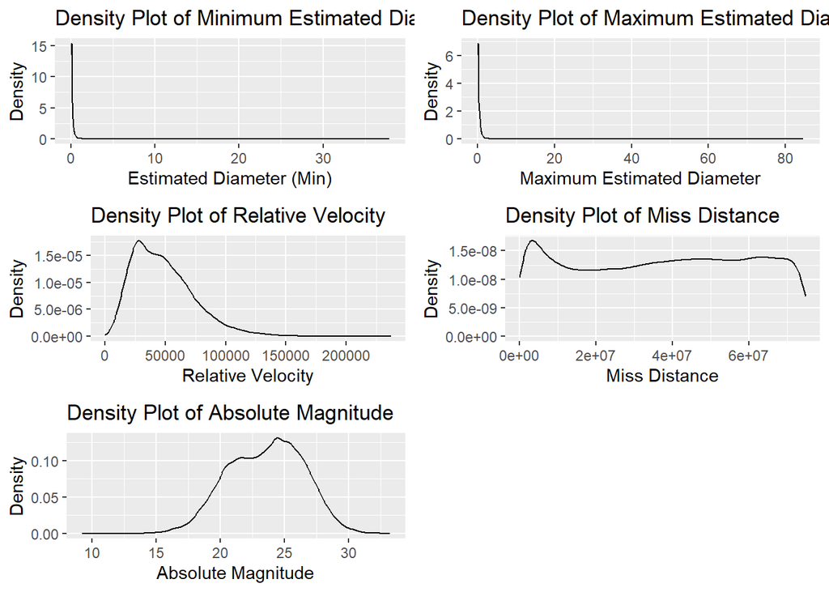

```r
plot1 <- ggplot(raw_data, aes(x = est_diameter_min)) +
  geom_density() +
  labs(x = "Estimated Diameter (Min)", y = "Density", title = "Density Plot of Minimum Estimated Diameter")
plot2 <- ggplot(raw_data, aes(x = est_diameter_max)) +
  geom_density() +
  labs(x = "Maximum Estimated Diameter", y = "Density", title = "Density Plot of Maximum Estimated Diameter")
plot3 <- ggplot(raw_data, aes(x = relative_velocity)) +
  geom_density() +
  labs(x = "Relative Velocity", y = "Density", title = "Density Plot of Relative Velocity")
plot4 <- ggplot(raw_data, aes(x = miss_distance)) +
  geom_density() +
  labs(x = "Miss Distance", y = "Density", title = "Density Plot of Miss Distance")
plot5 <- ggplot(raw_data, aes(x = absolute_magnitude)) +
  geom_density() +
  labs(x = "Absolute Magnitude", y = "Density", title = "Density Plot of Absolute Magnitude")

plot_grid(plot1, plot2, plot3, plot4, plot5, ncol = 2)
```

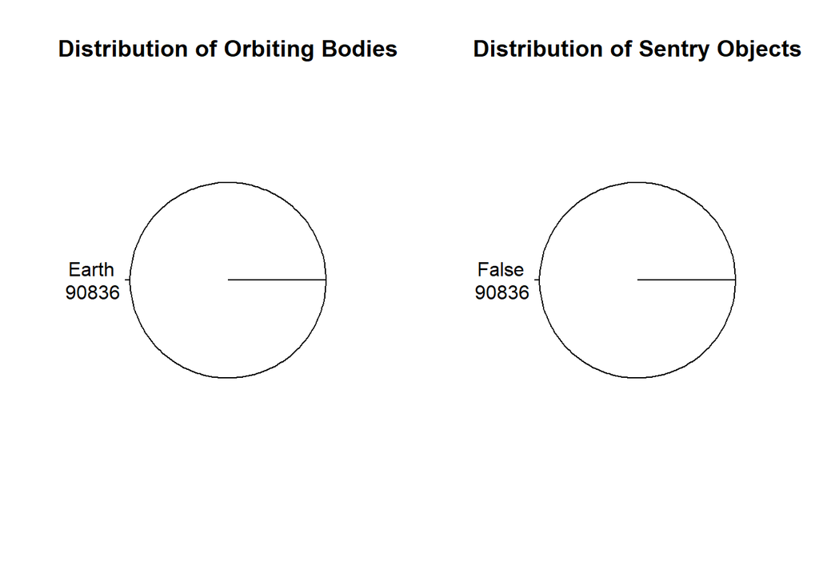

```r
par(mfrow = c(1, 2))
orbit_cat_count <- table(raw_data$orbiting_body)
pie_chart <- pie(orbit_cat_count, labels = paste(names(orbit_cat_count), "\n", orbit_cat_count), main = "Distribution of Orbiting Bodies")
sentry_cat_count <- table(raw_data$sentry_object)
pie_chart <- pie(sentry_cat_count, labels = paste(names(sentry_cat_count), "\n", sentry_cat_count), main = "Distribution of Sentry Objects")
```

Two things immediately stand out about our data; orbiting_body and sentry_object variables have no variance at all!

## Under-sampling

```r
data_unique <- raw_data %>% distinct(id, .keep_all = TRUE)

hazardous_data <- filter(data_unique, hazardous == "True")
non_hazardous_data <- filter(data_unique, hazardous == "False")

hazardous_samples <- nrow(hazardous_data)
non_hazardous_samples <- nrow(non_hazardous_data)

# Calculate the number of non-hazardous samples to be used for balancing
final_non_hazardous_samples <- min(hazardous_samples, non_hazardous_samples)

set.seed(123)
sampled_non_hazardous <- sample_n(non_hazardous_data, final_non_hazardous_samples)
final_dataset <- rbind(hazardous_data, sampled_non_hazardous)

set.seed(123)
final_dataset <- final_dataset[sample(nrow(final_dataset)),]

write.csv(final_dataset, "balanced_dataset.csv", row.names = FALSE)
```

# Feature Engineering

## Excluding Features

As we saw in our data exploration step, some columns offer uninformative information. These columns are mainly `orbiting_body` and `sentry_object` as they have no variability at all.

Other columns we want to exclude will be the `name` and `id` as they are not even features, rather identifiers for the objects.

# Principal Component Analysis(PCA)

```r
data <- read.csv("balanced_dataset.csv")
numerical_data <- data[, c("est_diameter_min", "est_diameter_max", "relative_velocity", "miss_distance", "absolute_magnitude")]

standardized_data <- scale(numerical_data)


pca_result <- prcomp(standardized_data)
```

## Getting Results

```r
#Step 5: Summary of results
summary(pca_result)
```

```
## Importance of components:
##                           PC1    PC2    PC3     PC4       PC5
## Standard deviation     1.6657 1.0795 0.8148 0.62936 6.708e-11
## Proportion of Variance 0.5549 0.2331 0.1328 0.07922 0.000e+00
## Cumulative Proportion  0.5549 0.7880 0.9208 1.00000 1.000e+00
```

The key insights:

-Once we look at the results we can see the first two principal components (PC1 and PC2) capture a significant amount of information (78.80% of the total variance). This suggests that these two components largely summarize the variability in our dataset - Based on the cumulative proportion of variance, one can decide how many principal components to retain. For instance, using the first four components (capturing 100% of the variance) would be a comprehensive representation of the data. -The negligible variance explained by PC5 suggests that it contributes little to the data structure and can be dropped without much loss of information.

# Clustering

## Clustering Analysis

In this analysis, we explored hierarchical clustering using different linkage methods on a dataset. The goal was to determine an optimal number of clusters for the data.

we performed hierarchical clustering using various linkage methods:

- **Complete Linkage:** This method uses the maximum pairwise distance between points in two clusters.
- **Single Linkage:** It considers the minimum pairwise distance between points in two clusters.
- **Average Linkage:** This method calculates the average pairwise distance between points in two clusters.
- **Centroid Linkage:** It uses the distance between the centroids of two clusters.
- **Median Linkage:** This method considers the median pairwise distance between points in two clusters.
- **McQuitty Linkage:** It is a modification of the average linkage method.
- **Ward D Linkage:** This method minimizes the variance of distances within clusters.
- **Ward D2 Linkage:** It is an alternative to Ward D that uses squared distances.

### Visualizing Dendrograms

Dendrograms for each hierarchical model were visualized, displaying the hierarchical structure of the data and the formation of clusters as the linkage threshold increases

### Determining Optimal Number of Clusters

The Elbow method was used to identify the optimal number of clusters. This method involves plotting the Within-Cluster Sum of Squares (WSS) for different numbers of clusters and selecting the ‘elbow’ point where the WSS begins to level off.

```r
# Load necessary libraries
library(factoextra)
```

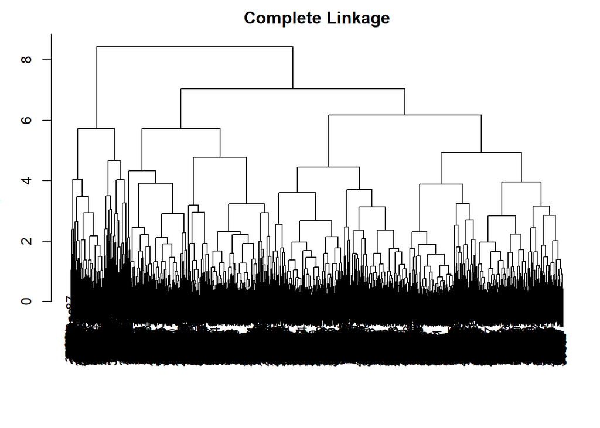

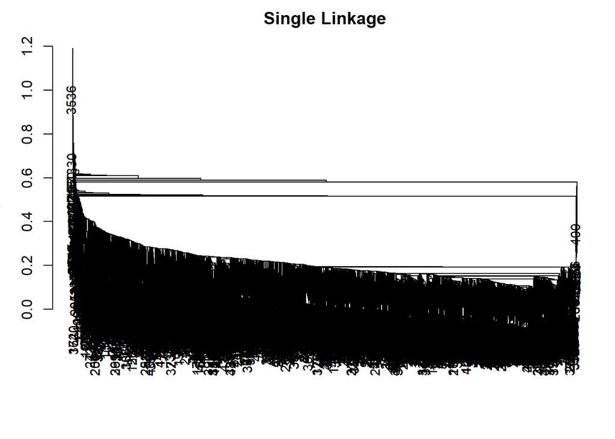

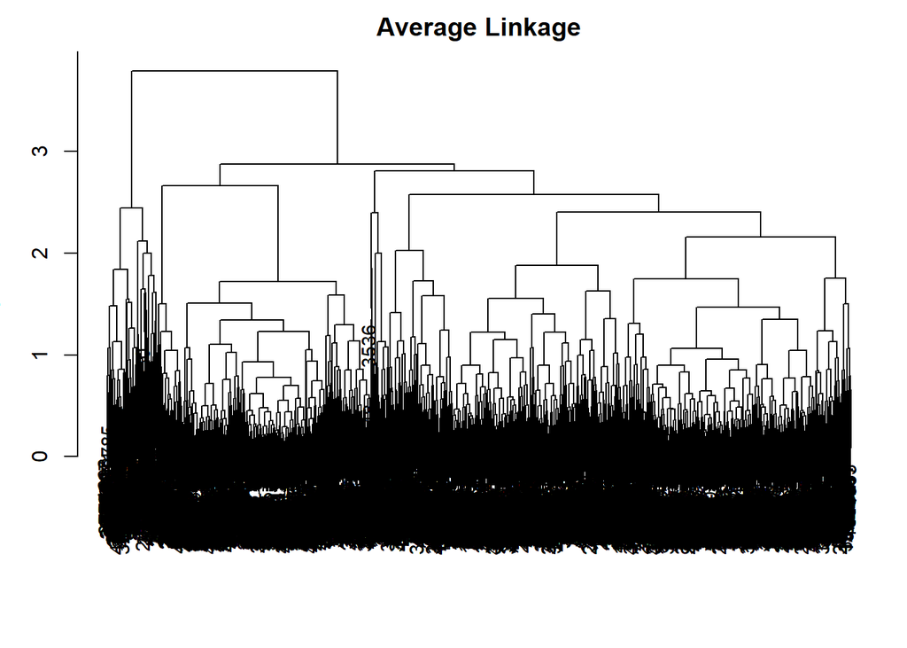

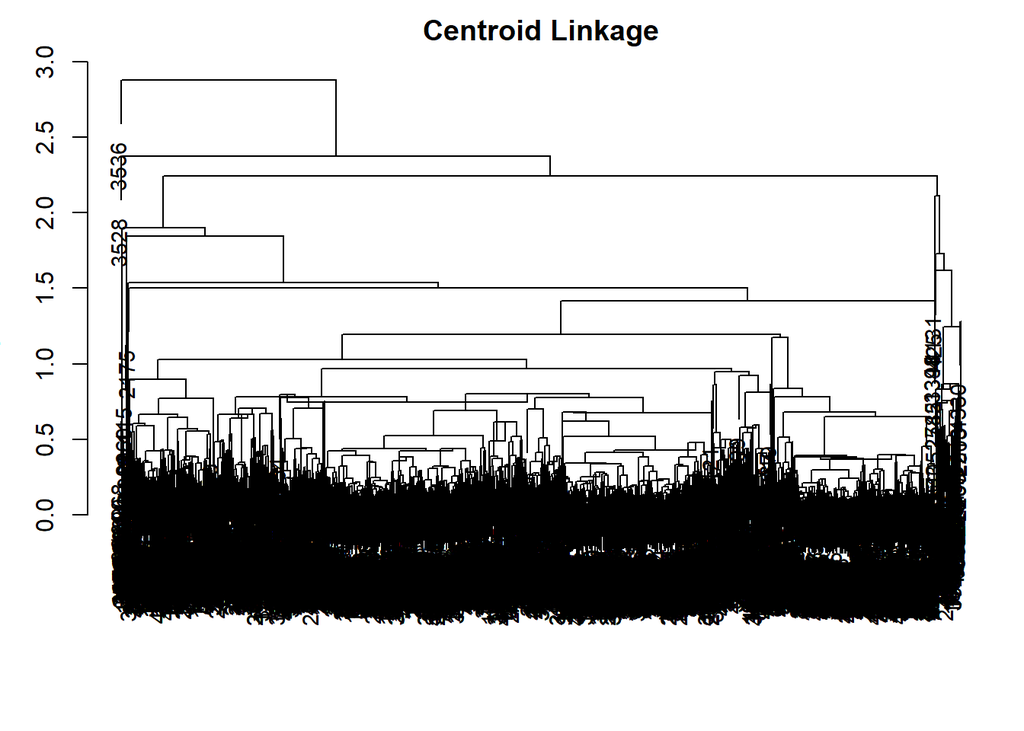

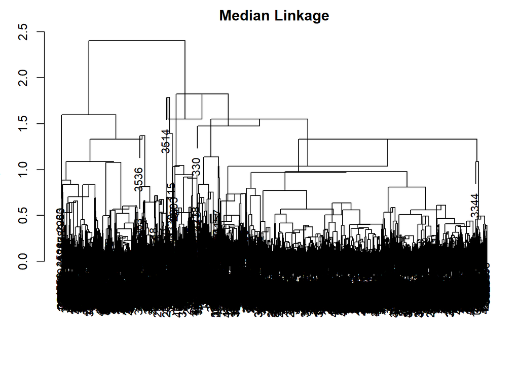

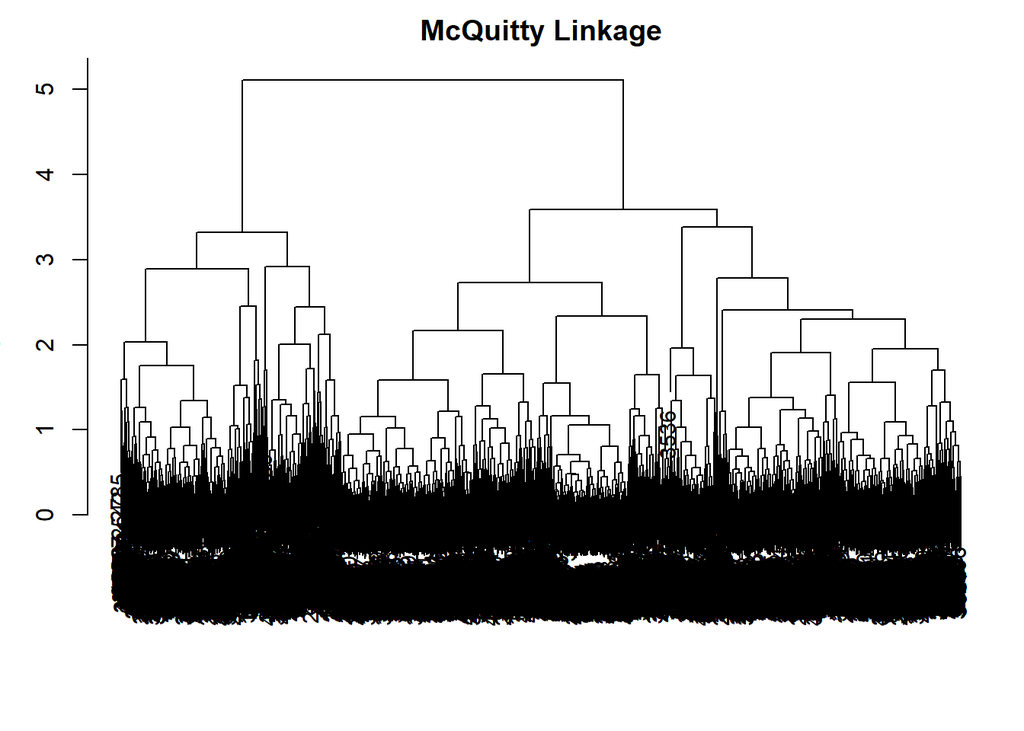

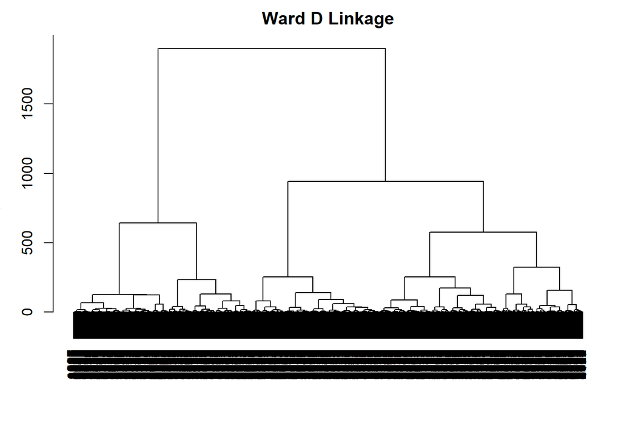

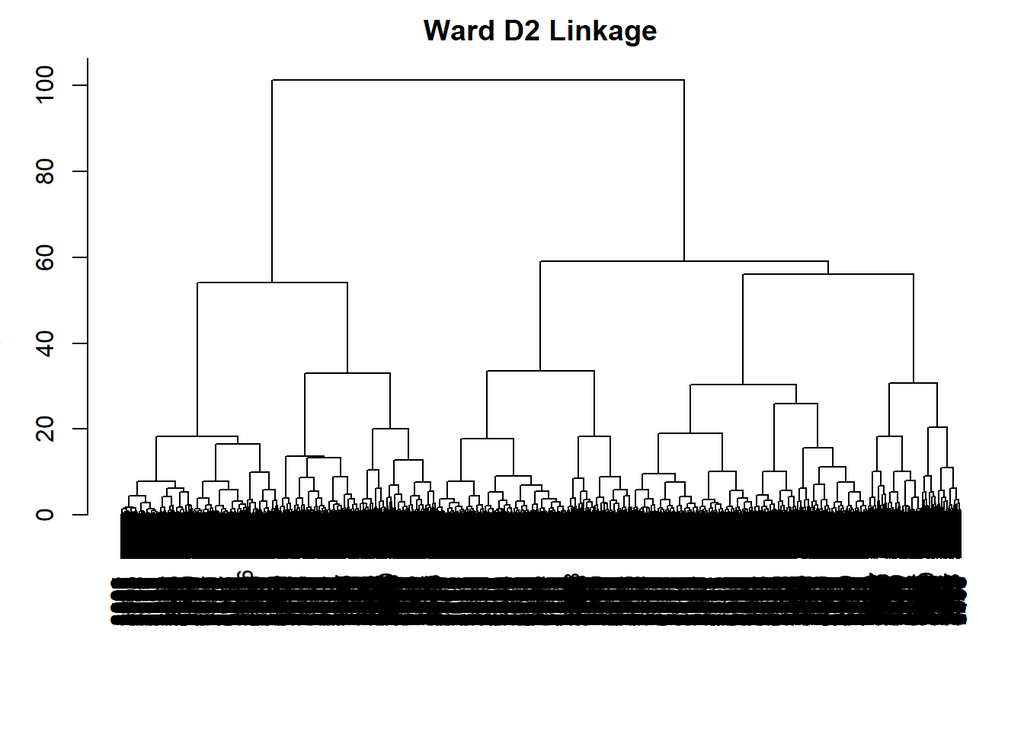

```r
library(cluster)

# Define the feature names and extract the features
feature_names <- c("absolute_magnitude", "miss_distance", "relative_velocity","est_diameter_max")
hclust_features <- data[feature_names]

# Scale the features
# Assuming 'data' is your original dataframe

# Calculate z-scores for each feature
z_scores <- scale(data[feature_names])

# Define a threshold for outliers (commonly 2.5 or 3)
threshold <- 2.5

# Identify outliers (any data point with a feature having z-score beyond the threshold)
outliers <- apply(z_scores, 1, function(x) any(abs(x) > threshold))

# Remove outliers from the data
data_clean <- data[!outliers, ]

# Proceed with the rest of your existing code, using 'data_clean' instead of 'data'
hclust_features <- data_clean[feature_names]
hclust_features_scaled <- scale(hclust_features)
# ... rest of your clustering code


# Perform hierarchical clustering using different linkage methods
complete_heir_model <- hclust(dist(hclust_features_scaled), method = "complete")
single_heir_model <- hclust(dist(hclust_features_scaled), method = "single")
average_heir_model <- hclust(dist(hclust_features_scaled), method = "average")
centroid_heir_model <- hclust(dist(hclust_features_scaled), method = "centroid")
median_heir_model <- hclust(dist(hclust_features_scaled), method = "median")
mcquitty_heir_model <- hclust(dist(hclust_features_scaled), method = "mcquitty")
ward.D_heir_model <- hclust(dist(hclust_features_scaled), method = "ward.D")
ward.D2_heir_model <- hclust(dist(hclust_features_scaled), method = "ward.D2")

# Visualize the dendrograms for each hierarchical model
plot_list <- list(complete_heir_model, single_heir_model, average_heir_model,
                  centroid_heir_model, median_heir_model, mcquitty_heir_model,
                  ward.D_heir_model, ward.D2_heir_model)
names(plot_list) <- c("Complete", "Single", "Average", "Centroid", "Median", "McQuitty", "Ward D", "Ward D2")

# Adjust global plot margins
par(mar = c(3, 3, 2, 1))

# Plot Dendrograms
for (i in 1:length(plot_list)) {
  plot(plot_list[[i]], main = paste(names(plot_list)[i], "Linkage"),
       xlab = "", sub = "", cex = .9)
}
```

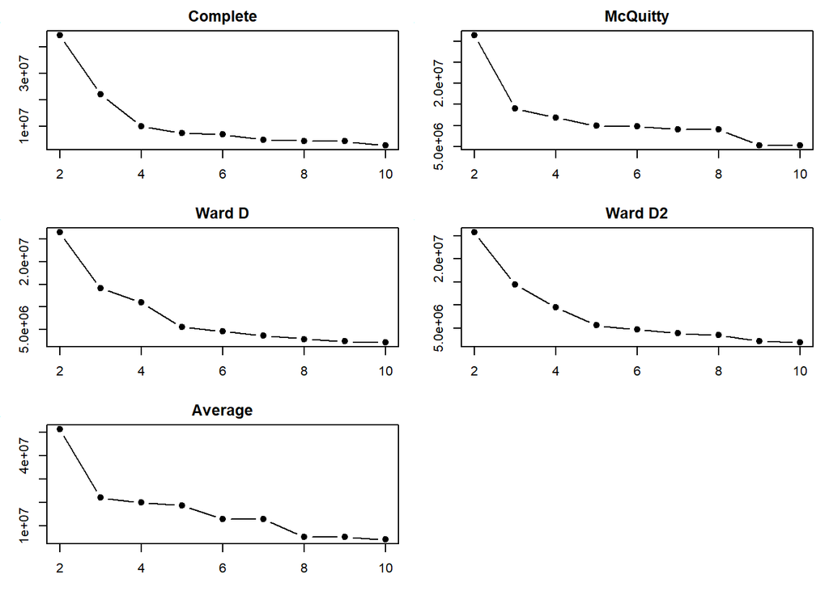

```r
# Function to calculate WSS
calculate_wss <- function(hclust_model, data, max_clusters = 10) {
  sapply(2:max_clusters, function(k){
    clustering <- cutree(hclust_model, k)
    sum(sapply(1:k, function(cluster){
      cluster_points <- data[clustering == cluster, ]
      sum(dist(cluster_points)^2)
    }))
  })
}

max_clusters <- 10

# Filter plot_list to include Complete, McQuitty, Ward D, Ward D2, and Average models
selected_models <- c("Complete", "McQuitty", "Ward D", "Ward D2", "Average")
selected_plot_list <- plot_list[selected_models]
names(selected_plot_list) <- selected_models

# Apply the WSS calculation function to each of the selected hierarchical models
selected_wss_values <- lapply(selected_plot_list, calculate_wss, data = hclust_features_scaled, max_clusters = max_clusters)

# Plot the Elbow Curve for the selected models
par(mfrow = c(3, 2)) # Adjust layout for 5 plots
for (i in 1:length(selected_wss_values)) {
  plot(2:max_clusters, selected_wss_values[[i]], type = "b", pch = 19, xlab = "Number of clusters K",
       ylab = "Total within-cluster sum of squares", main = names(selected_wss_values)[i])
}
```

The complete,mcquitty, Ward D,ward D2 and average tended to yielded more evenly sized clusters whereas the others lead to more extended and unevenly sized clusters.

### Cutting Dendrograms at Specific Heights

To further explore this, we cut the dendrograms at specific heights to examine the clusters formed

PCA was employed for dimensionality reduction, and scatter plots were created to visualize the clusters from different linkage methods. These plots helped in understanding the distribution and separation of clusters.

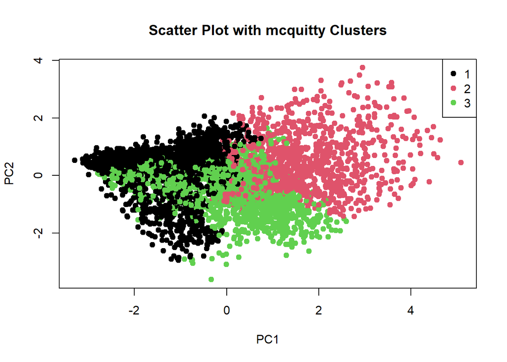

```r
# Cutting the dendrograms at specified heights
clusters_wardD2 <- cutree(ward.D2_heir_model, h = 59)
clusters_wardD <- cutree(ward.D_heir_model, h = 900)
clusters_complete <- cutree(complete_heir_model, h = 7)
clusters_mcquitty <- cutree(mcquitty_heir_model, h = 3.5)
clusters_average <- cutree(average_heir_model, h = 2.85)

# Cluster plots using factoextra
# Example: Using PCA for dimensionality reduction
pca_result <- prcomp(hclust_features_scaled)
pca_data <- as.data.frame(pca_result$x)

# Add cluster assignments to the PCA data
pca_data$cluster_wardD2 <- as.factor(clusters_wardD2)
pca_data$cluster_wardD <- as.factor(clusters_wardD)
pca_data$cluster_complete <- as.factor(clusters_complete)
pca_data$cluster_mcquitty <- as.factor(clusters_mcquitty)
pca_data$cluster_average <- as.factor(clusters_average)


# Scatter plot for Ward D2 clusters
plot(pca_data$PC1, pca_data$PC2, col=pca_data$cluster_mcquitty, pch=19, xlab="PC1", ylab="PC2", main="Scatter Plot with mcquitty Clusters")
legend("topright", legend=levels(pca_data$cluster_mcquitty), col=1:length(levels(pca_data$cluster_wardD2)), pch=19)
```

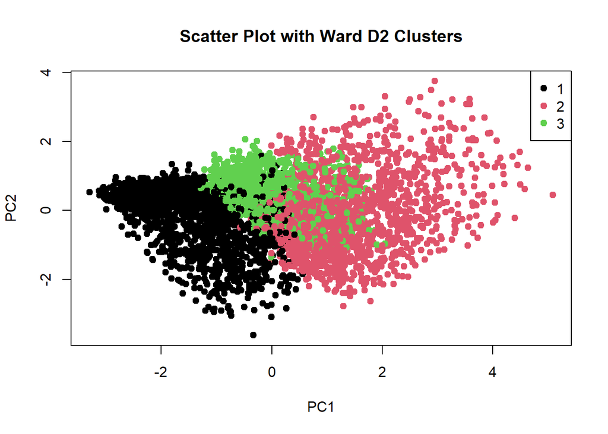

```r
# Scatter plot for Ward D2 clusters
plot(pca_data$PC1, pca_data$PC2, col=pca_data$cluster_wardD2, pch=19, xlab="PC1", ylab="PC2", main="Scatter Plot with Ward D2 Clusters")
legend("topright", legend=levels(pca_data$cluster_wardD2), col=1:length(levels(pca_data$cluster_wardD2)), pch=19)
```

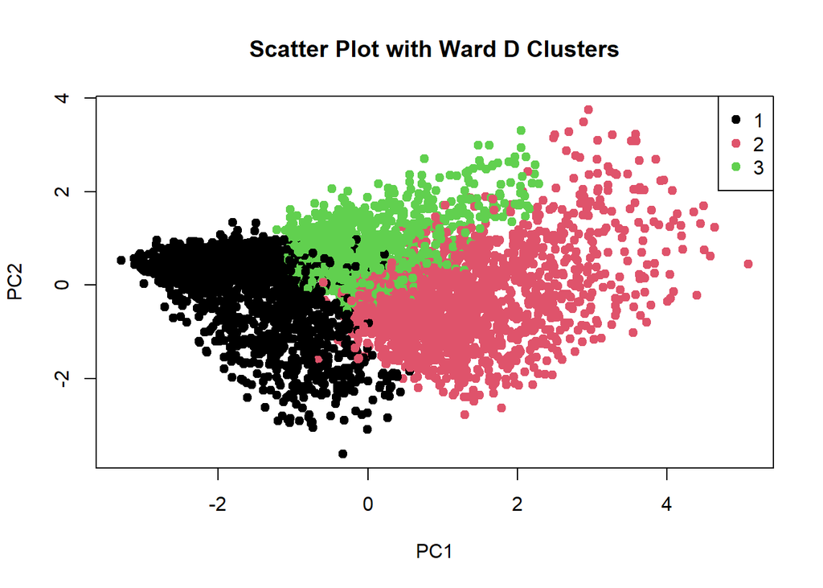

```r
# Scatter plot for Ward D2 clusters
plot(pca_data$PC1, pca_data$PC2, col=pca_data$cluster_wardD, pch=19, xlab="PC1", ylab="PC2", main="Scatter Plot with Ward D Clusters")
legend("topright", legend=levels(pca_data$cluster_wardD), col=1:length(levels(pca_data$cluster_wardD2)), pch=19)
```

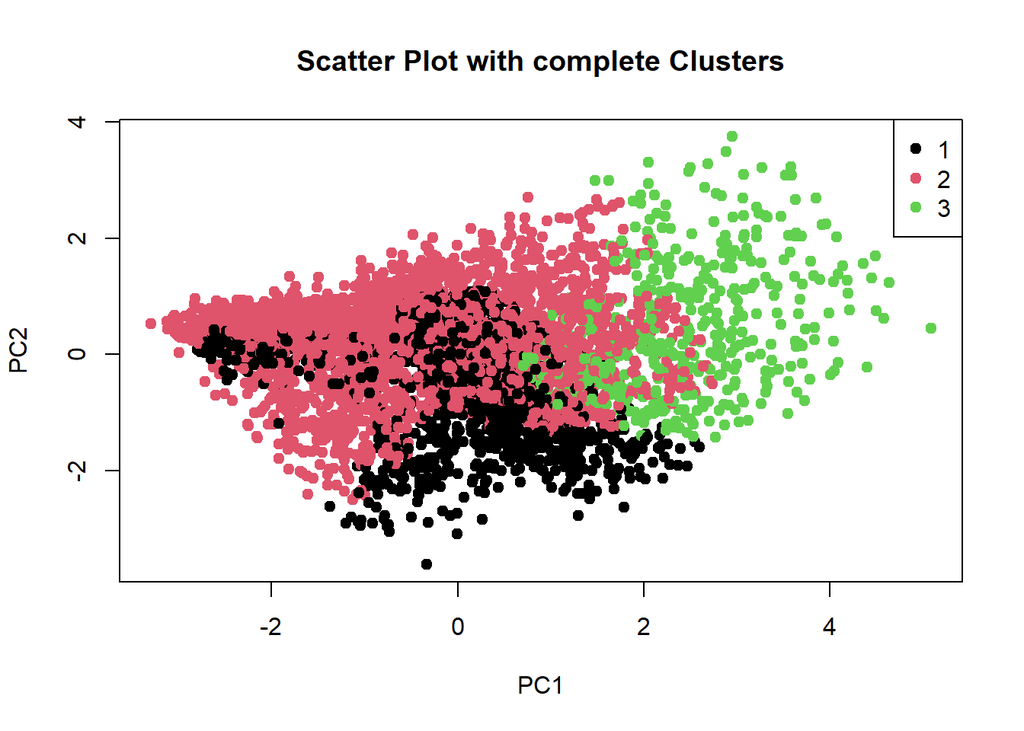

```r
# Scatter plot for Ward D2 clusters
plot(pca_data$PC1, pca_data$PC2, col=pca_data$cluster_complete, pch=19, xlab="PC1", ylab="PC2", main="Scatter Plot with complete Clusters")
legend("topright", legend=levels(pca_data$cluster_complete), col=1:length(levels(pca_data$cluster_wardD2)), pch=19)
```

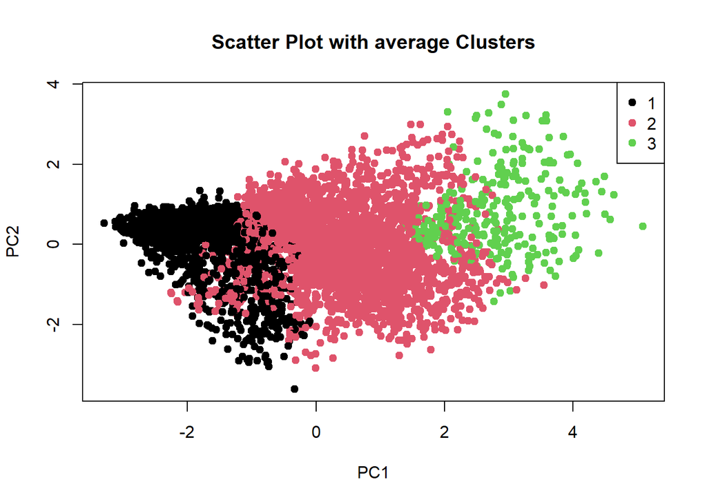

```r
plot(pca_data$PC1, pca_data$PC2, col=pca_data$cluster_average, pch=19, xlab="PC1", ylab="PC2", main="Scatter Plot with average Clusters")
legend("topright", legend=levels(pca_data$cluster_average), col=1:length(levels(pca_data$cluster_wardD2)), pch=19)
```

## K-means Clustering

In this analysis, we applied K-means clustering to the dataset after preprocessing and dimensionality reduction using PCA (Principal Component Analysis). The choice of the number of clusters (K) was informed by the results of the hierarchical clustering analysis, where we identified an optimal K=3.

### Dimensionality Reduction with PCA

We performed PCA on the scaled features to reduce dimensionality and obtain the first four principal components (PC1, PC2, PC3, and PC4). These principal components capture the most significant variability in the data.

### K-means Clustering

Using the PCA-transformed data, we applied K-means clustering with K=3 clusters. The choice of K=3 was based on the results of the hierarchical clustering analysis, where we observed that three clusters were suitable for this dataset.

We used a random seed for reproducibility and applied the K-means algorithm with 20 different starting configurations (nstart=20) to mitigate the risk of converging to local minima.

### Visualizing K-means Clusters

To visualize the clusters in a 3D space, we created a 3D scatter plot using the first three principal components (PC1, PC2, and PC3) as axes. Each point in the plot represents an observation, color-coded by its assigned cluster. This plot allows us to see how the data points are grouped into three clusters.

Additionally, we created a 2D scatter plot using the first two principal components (PC1 and PC2) to provide a clearer view of the clusters in two-dimensional space. The points are colored by their cluster assignments, and this plot helps visualize the separation of data points along the first two principal components.

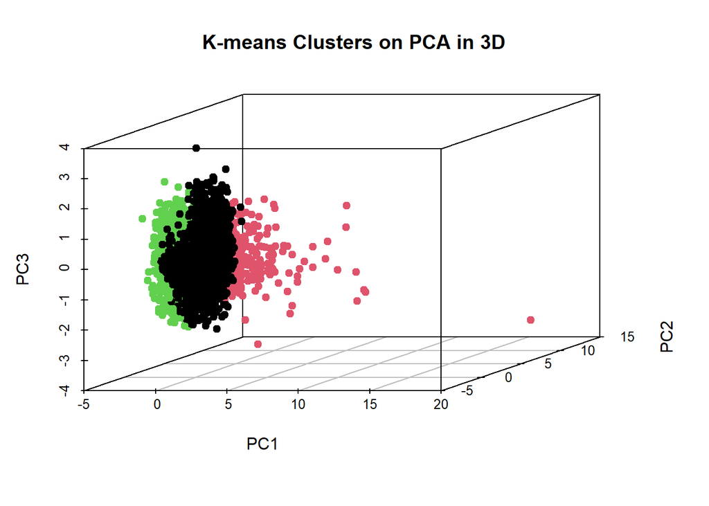

```r
numerical_data <- data[, c("est_diameter_max", "relative_velocity", "miss_distance", "absolute_magnitude")]

kmeans_features_scaled <- scale(numerical_data)

pca_result <- prcomp(kmeans_features_scaled)
pca_data <- pca_result$x[, 1:4]

set.seed(123)  # For reproducibility
kmeans_pca <- kmeans(pca_data, 3, nstart = 20)
pca_data <- as.data.frame(pca_data)
pca_data$cluster <- kmeans_pca$cluster

scatterplot3d(pca_data[,1], pca_data[,2], pca_data[,3],
              color = pca_data$cluster, pch = 19,
              xlab = "PC1", ylab = "PC2", zlab = "PC3",
              main = "K-means Clusters on PCA in 3D")
```

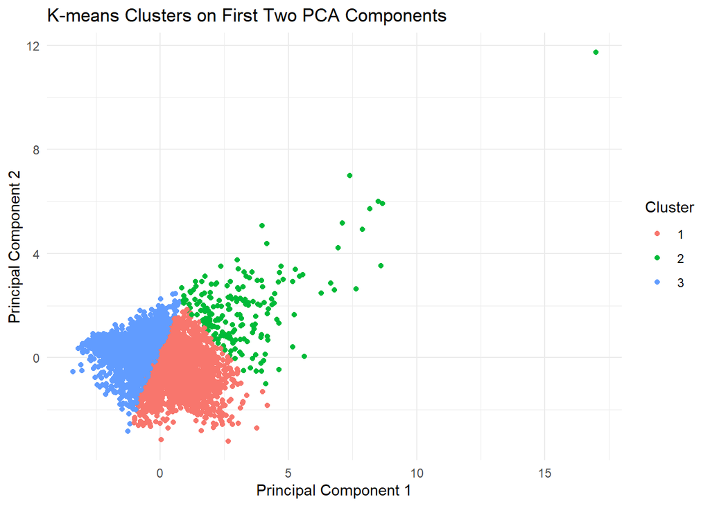

```r
# Extract the first two principal components

pca_data_2d <- pca_data[, 1:4]
pca_data_2d$cluster <- as.factor(pca_data$cluster)

# Create a 2D scatter plot
ggplot(pca_data_2d, aes(x = PC1, y = PC2, color = cluster)) +
  geom_point() +
  labs(title = "K-means Clusters on First Two PCA Components",
       x = "Principal Component 1",
       y = "Principal Component 2",
       color = "Cluster") +
  theme_minimal()
```

# Model Development

## Decision Trees

The first of a few models we will be trying is Decision Trees.

```r
feature_names <- c("absolute_magnitude", "miss_distance", "relative_velocity", "est_diameter_min", "est_diameter_max")
features <- data[feature_names]
target <- factor(data$hazardous)

features_scaled <- scale(features)
set.seed(123)
splitIndex <- createDataPartition(data$hazardous, p = .8, list = FALSE)
X_train <- features_scaled[splitIndex,]
X_test <- features_scaled[-splitIndex,]
y_train <- target[splitIndex]
y_test <- target[-splitIndex]
```

### Fitting the Model

The decision tree model was constructed using the rpart function in R, targeting the prediction of hazardous vs. non-hazardous objects. The features included in the model were estimated minimum diameter, relative velocity, miss distance, and absolute magnitude.

```r
model <- rpart(y_train ~ est_diameter_min + relative_velocity + miss_distance + absolute_magnitude,
               data = as.data.frame(X_train),
               method = "class",
)
```

The structure of the decision tree was visualized using rpart.plot to provide insights into the decision-making process of the model

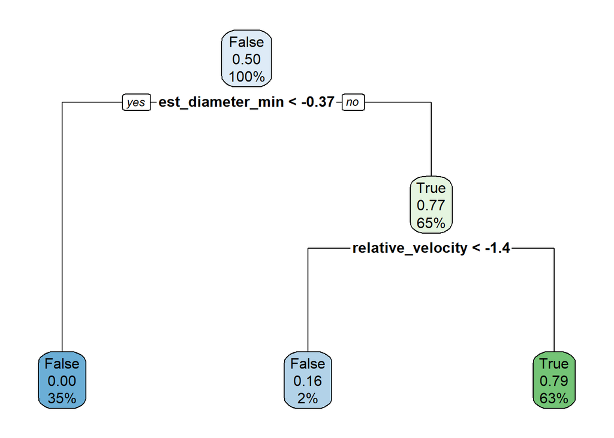

```r
rpart.plot(model)
```

### Model Evaluation

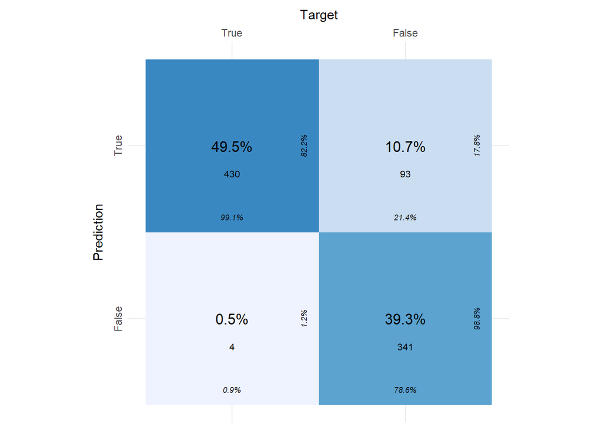

```r
predictions <- predict(model, newdata = as.data.frame(X_test), type = "class")
suppressWarnings({
confusion_matrix <- cvms::confusion_matrix(targets = y_test, predictions = predictions)
plot_confusion_matrix(confusion_matrix$`Confusion Matrix`[[1]])})
```

```r
original_specificity <- confusion_matrix$Specificity
original_sensitivity <- confusion_matrix$Sensitivity
original_f1 <- confusion_matrix$F1
accuracy <- mean(predictions == y_test)
print(paste("Accuracy",accuracy))
```

```
## [1] "Accuracy 0.888248847926267"
```

```r
print(paste("Balanced Accuracy",confusion_matrix$`Balanced Accuracy`))
```

```
## [1] "Balanced Accuracy 0.888248847926267"
```

```r
print(paste("Specificity:", original_specificity))
```

```
## [1] "Specificity: 0.785714285714286"
```

```r
print(paste("Sensitivity (Recall):", original_sensitivity))
```

```
## [1] "Sensitivity (Recall): 0.990783410138249"
```

```r
print(paste("Original Model F1 Score:", original_f1))
```

```
## [1] "Original Model F1 Score: 0.898641588296761"
```

The model demonstrated a high sensitivity rate of 99.07%, signifying its adeptness in accurately identifying hazardous objects. This attribute is particularly vital in the context of planetary defense, where the primary objective is to minimize the risk of overlooking potentially dangerous NEOs.

In essence, the decision tree model exhibits a pronounced capability in identifying hazardous objects, with a preferential error mode towards overestimation of risk. While the model demonstrates slightly lower specificity and precision, its exceptional sensitivity is of paramount importance in the realm of planetary defense against NEOs. This model orientation towards safety underscores its utility in applications where the cost of missing a hazardous object far outweighs the inconvenience of false alarms..

### Improvements

We noticed that initially, the tree is too focused on one feature, so we experimented with a few things to increase the model depth, but none of the methods we tried yielded any improvements except for increasing model complexity, with a very slight improvement in specificity as can be seen below:

```r
complex_model <- rpart(y_train ~ est_diameter_min + est_diameter_max + relative_velocity + miss_distance + absolute_magnitude,
               data = as.data.frame(X_train),
               method = "class",
               control = rpart.control(cp = 0.001),


)
```

Let’s also visualize the changes to the tree

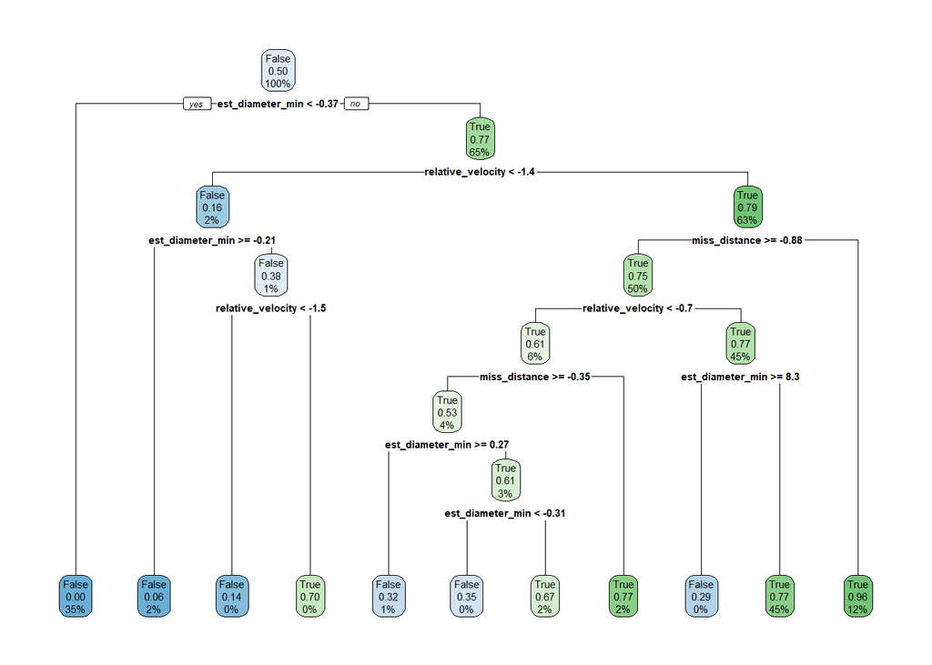

```r
rpart.plot(complex_model)
```

And let’s examine the improvement:

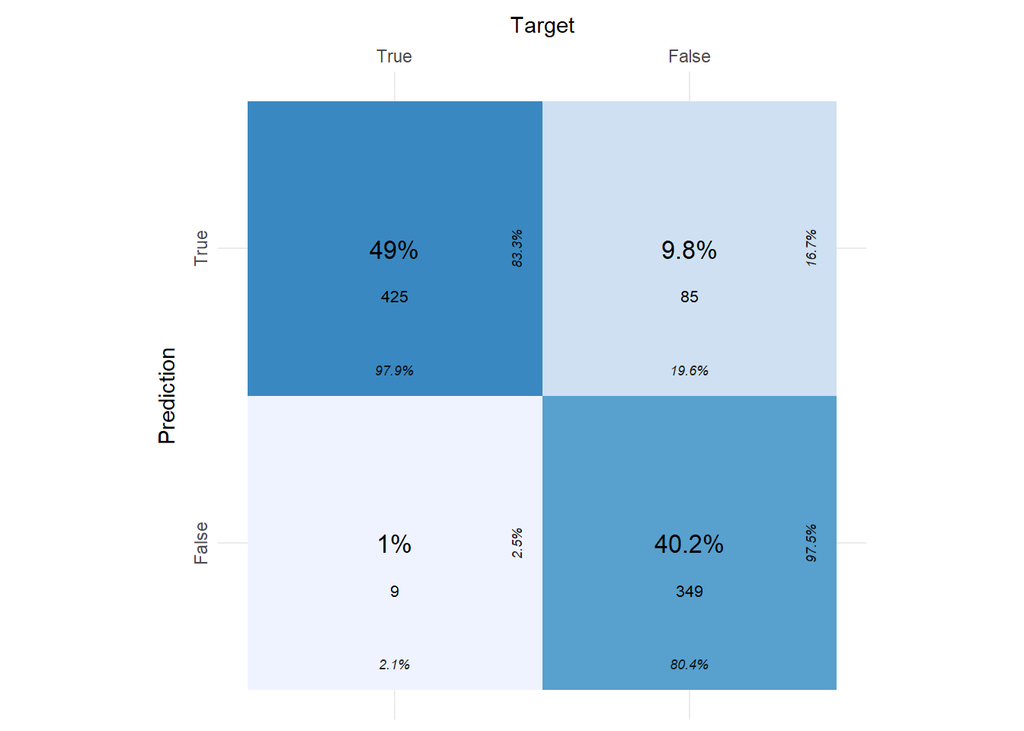

```r
complex_predictions <- predict(complex_model, newdata = as.data.frame(X_test), type = "class")

complex_confusion_matrix <- cvms::confusion_matrix(targets = y_test, predictions = complex_predictions)
suppressWarnings({plot_confusion_matrix(complex_confusion_matrix$`Confusion Matrix`[[1]])})
```

```r
complex_specificity <- complex_confusion_matrix$Specificity
complex_sensitivity <- complex_confusion_matrix$Sensitivity
complex_f1 <- complex_confusion_matrix$F1
```

```r
complex_accuracy <- mean(complex_predictions == y_test)
print(paste("Complex Model accuracy",complex_accuracy))
```

```
## [1] "Complex Model accuracy 0.891705069124424"
```

```r
print(paste("Complex Model Balanced accuracy",complex_confusion_matrix$`Balanced Accuracy`))
```

```
## [1] "Complex Model Balanced accuracy 0.891705069124424"
```

```r
print(paste("Complex Model Specificity:", complex_specificity))
```

```
## [1] "Complex Model Specificity: 0.804147465437788"
```

```r
print(paste("Complex Model Sensitivity (Recall):", complex_sensitivity))
```

```
## [1] "Complex Model Sensitivity (Recall): 0.97926267281106"
```

```r
print(paste("Complex Model F1 Score:", complex_f1))
```

```
## [1] "Complex Model F1 Score: 0.900423728813559"
```